# Kaggle Housing Sale Price Prediction

Name: YANFANG GUO

E-mail:yanfang.guo@vub.be

Master of Applied Computer Science,VUB

# Abstract

The housing Sale prices problem is a regression problem. It contains 79 features which describe the quality and quantity of the property. Machine learning algorithms are applied to this supervised regression problem. Here I use the **filter and wrapper method** together to select the features. First use the **correlation** between the feature and Sale Price to filter some really uncorrelated features, then use the **wrapper method** to select the features. Three models includes **simple linear regression, LASSO, and SVM** are selected to predict the price. Finally, to increse the robustness of the model, I use the **random subspace and bagging** methods to combine the models together. The best score in Kaggle is 0.12747.

# Introduction

## Goals

1. Predict the price for the test dataset.
2. Apply Machine techniques to real life problems.
3. Learn how to clean the data.
4. Learn feature selection techniques.
5. Explore the machine learning models performance on regression problem with both category and numeric input and select the parameters for the algorithm.
6. Learn to work with the programming language R.

## Report structure

# Feature Selection

**Flow Chart of Feature Selection Procedure**

[figure not shown]

## Deal with Null Values

```python
library(nnet)
library(e1071)

library(ggplot2)
library(MASS)
setwd("~/Documents/ML_Kaggle")
train <- read.csv("~/Documents/ML_Kaggle/train.csv")
test<-read.csv("test.csv")
```

### An overview of Missing Values

Here we print all values with NA, and discard feature with missing values more than 800

```python
Id<-test$Id
temp<-colSums(apply(train,2,is.na))
temp[temp>0]

del_attr <- c(names(temp[temp > 800]))
del_attr <- c(del_attr, "PoolArea", "MiscVal")
for (i in del_attr) {
  train[[i]] <- NULL
}
print("The delete features:(more than 800 NA's):")
del_attr
```

**LotFrontage**

259

**Alley**

1369

**MasVnrType**

8

**MasVnrArea**

8

**BsmtQual**

37

**BsmtCond**

37

**BsmtExposure**

38

**BsmtFinType1**

37

**BsmtFinType2**

38

**Electrical**

1

**FireplaceQu**

690

**GarageType**

81

**GarageYrBlt**

81

**GarageFinish**

81

**GarageQual**

81

**GarageCond**

81

**PoolQC**

1453

**Fence**

1179

**MiscFeature**

1406

```
[1] "The delete features:(more than 800 NA's):"
```

1. 'Alley'

2. 'PoolQC'

3. 'Fence'

4. 'MiscFeature'

5. 'PoolArea'

6. 'MiscVal'

### FillNa

Here I write a function fillNa to fill all NA's. It works like this:

```
1. stored all no Na in a vector
2. for missing values, random select a value using runif() in vector.
```

```python
# fillNa
fillNa <- function(x) {
  noNa <- x[!is.na(x)]
  for (i in 1:length(x)) {
    if (is.na(x[i])) {
      index = round(runif(1, min = 1, max = length(noNa)))
      x[i] <- noNa[index]
    }
  }
  return (x)
}

# fill all NA
for (i in seq(length(train))) {
  train[[i]] <- fillNa(train[[i]])
}
```

## Analyse the SalePrice

Before we begin our feature selection procedure, we analyse the Saleprice. We notice the Skewness of SalePrice is 1.879 and we do a logrithm transform, later lower the skewness to 0.12, more close to normal distribution.

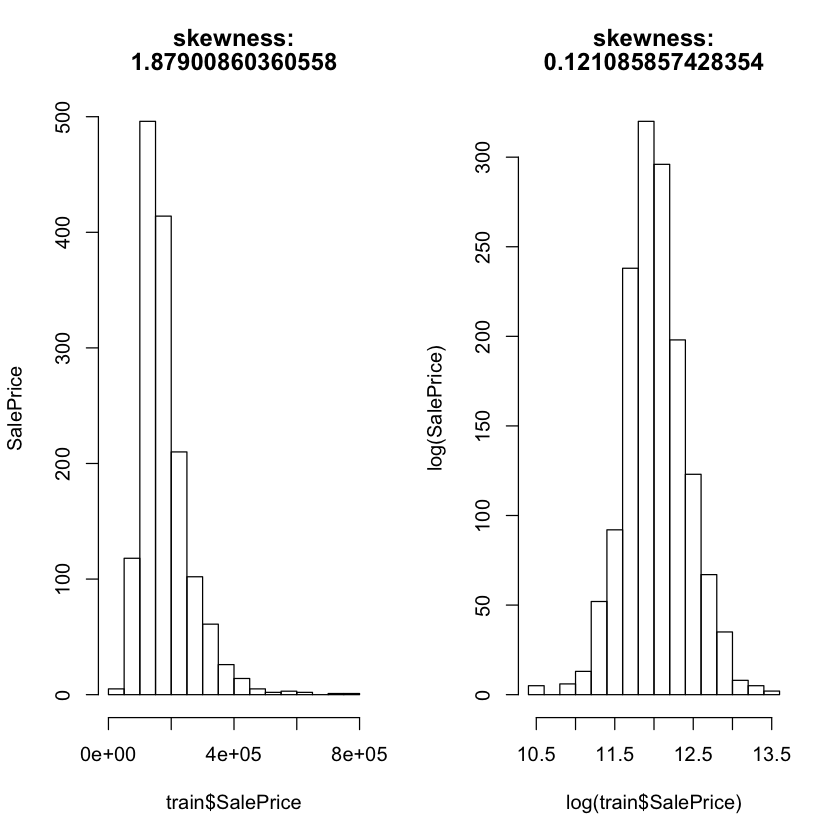

```python
par(mfrow=c(1,2))
hist(train$SalePrice,ylab="SalePrice",main=c("skewness:",skewness(train$SalePrice)))

hist(log(train$SalePrice),ylab="log(SalePrice)",main=c("skewness:",skewness(log(train$SalePrice))))

train$SalePrice<- log(train$SalePrice)
```

## Visualisation: An OverView of the Entire Dataset

For all the features, we draw the graph with x= feature,y=price and calculate the correlations. For attributes with very **low correlation**, we **discard these features**

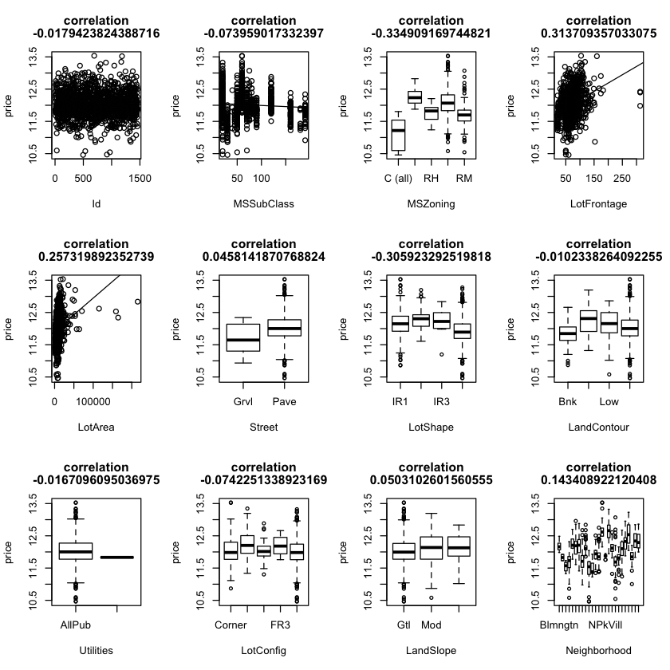

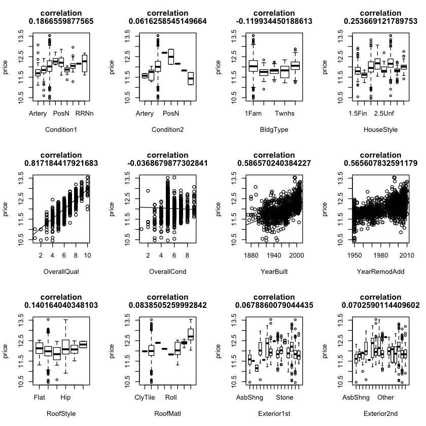

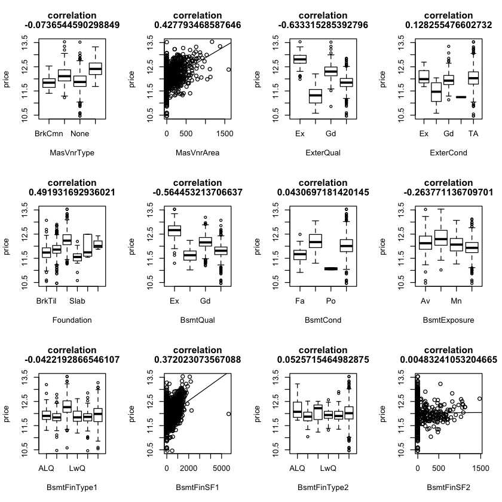

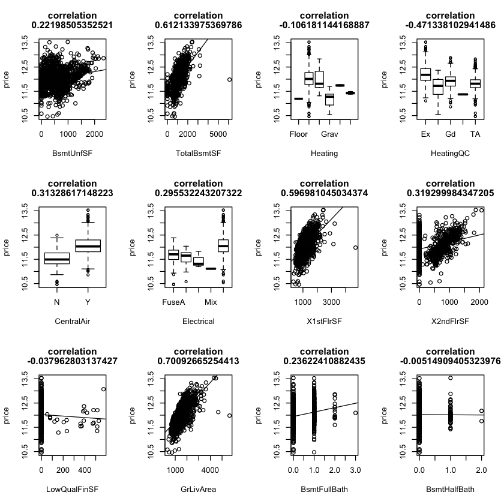

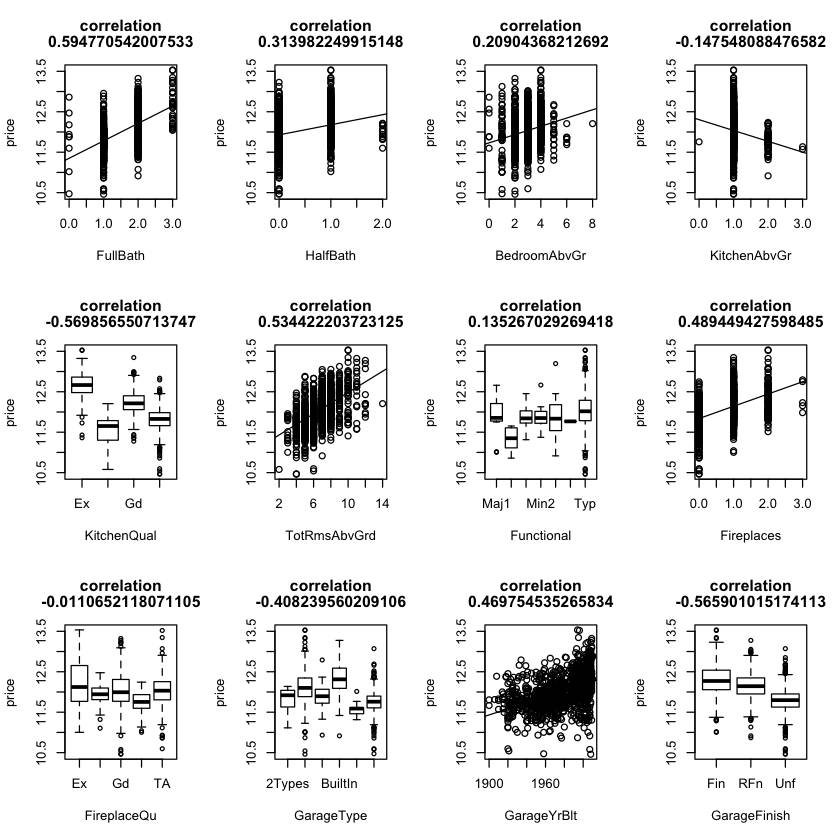

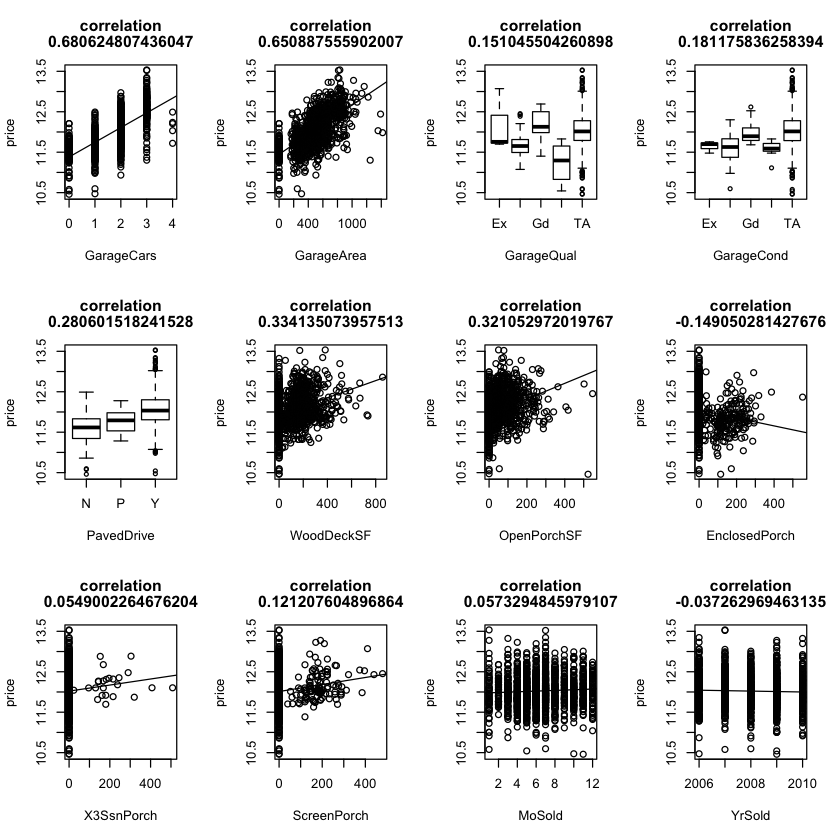

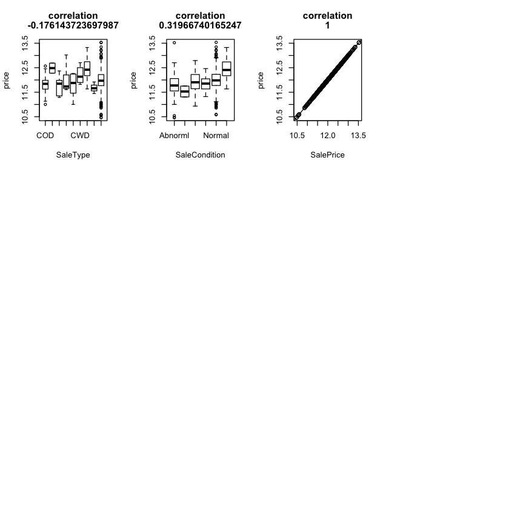

```python
price<-train$SalePrice
corre_seq_nna<- c()
par(mfrow=c(3,4))
for (i in names(train)){
     if(class(train[[i]])=='factor'){
     b<- train[[i]]
     temp <- data.frame(b[!is.na(b)],price[which(!is.na(b))])
     plot(temp[,1],temp[,2],main=c("correlation",cor(as.numeric(temp[,1]),temp[,2],method = 'spearman')),xlab=i,ylab='price')
     corre_seq_nna<-c(corre_seq_nna,cor(as.numeric(temp[,1]),temp[,2],method = 'spearman'))
     }else{
       b<- train[[i]]
       temp <- data.frame(b[!is.na(b)],price[which(!is.na(b))])
       plot(temp[,1],temp[,2],main=c("correlation",cor(temp[,1],temp[,2])),xlab=i,ylab='price')
       corre_seq_nna<-c(corre_seq_nna,cor(temp[,1],temp[,2]))
       abline(lm(temp[,2]~temp[,1]))
     }
   }

name_attr<-names(train)
temp<-which(abs(corre_seq_nna)<0.1)
del_attr<-c(del_attr,name_attr[temp])
train[name_attr[temp]]<-NULL
```

## Delete uncorrelated features

```python
print("Deleting Features in this filter technique in the Correlation round:")
name_attr[temp]
```

```
[1] "Deleting Features in this filter technique in the Correlation round:"
```

1. 'Id'

2. 'MSSubClass'

3. 'Street'

4. 'LandContour'

5. 'Utilities'

6. 'LotConfig'

7. 'LandSlope'

8. 'Condition2'

9. 'OverallCond'

10. 'RoofMatl'

11. 'Exterior1st'

12. 'Exterior2nd'

13. 'MasVnrType'

14. 'BsmtCond'

15. 'BsmtFinType1'

16. 'BsmtFinType2'

17. 'BsmtFinSF2'

18. 'LowQualFinSF'

19. 'BsmtHalfBath'

20. 'FireplaceQu'

21. 'X3SsnPorch'

22. 'MoSold'

23. 'YrSold'

## Feature classification

Here we classify the features in two categories and apply different techniques to different features.

- Numeric Features
- Category Features

```python
is.goodAttr <- function(x) {
  print(cor(as.numeric(x), price))
  plot(x, price)
  hist(as.numeric(x))
}
lm_test_attr <- function(testMat) {
  t.lm <- lm(price ~ ., testMat)
  index <- sample(1:nrow(testMat), round(0.5 * nrow(testMat)))
  print(summary(t.lm))
  pr.lm <- predict(t.lm, testMat[-index,])
  error.lm <-
    sqrt(sum((testMat[-index, length(testMat)] - pr.lm) ^ 2) / length(pr.lm))
  return(error.lm)
}

num_attr <- c()
cat_attr <- c()
for (i in names(train)) {
  if (class(train[[i]]) != "factor") {
    num_attr <- c(num_attr, i)
  } else{
    cat_attr <- c(cat_attr, i)
  }
}


a<-cbind(num_attr,cat_attr)
colnames(a)<-c("Numeric Feature","Category Feature")
a
```

| numeric Feature | Category Feature |
| --- | --- |
| LotFrontage | MSZoning |
| LotArea | LotShape |
| OverallQual | Neighborhood |
| YearBuilt | Condition1 |
| YearRemodAdd | BldgType |
| MasVnrArea | HouseStyle |
| BsmtFinSF1 | RoofStyle |
| BsmtUnfSF | ExterQual |
| TotalBsmtSF | ExterCond |
| X1stFlrSF | Foundation |
| X2ndFlrSF | BsmtQual |
| GrLivArea | BsmtExposure |
| BsmtFullBath | Heating |
| FullBath | HeatingQC |
| HalfBath | CentralAir |
| BedroomAbvGr | Electrical |
| KitchenAbvGr | KitchenQual |
| TotRmsAbvGrd | Functional |
| Fireplaces | GarageType |
| GarageYrBlt | GarageFinish |
| GarageCars | GarageQual |
| GarageArea | GarageCond |
| WoodDeckSF | PavedDrive |
| OpenPorchSF | SaleType |
| EnclosedPorch | SaleCondition |
| ScreenPorch | MSZoning |
| SalePrice | LotShape |

## For all Correlation, draw correlation map

For all numeric function, we draw correlation map

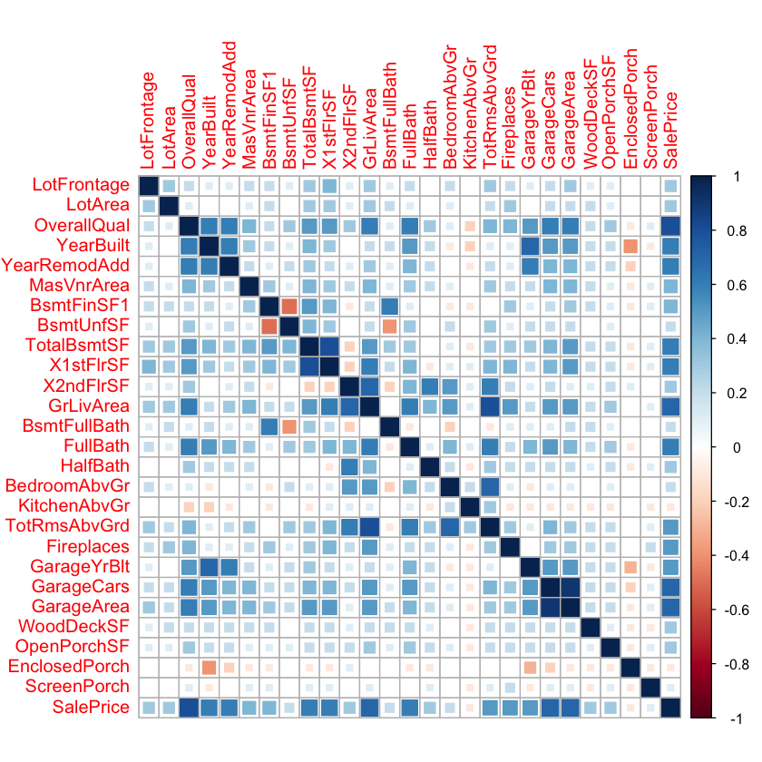

```python
library(corrplot)
m<-NULL
for (i in num_attr){
  m<-cbind(m,train[[i]])
}
names(m)<-num_attr
mcor<-cor(m)
mcor<-round(mcor*10)/10
colnames(mcor)<-num_attr
rownames(mcor)<-num_attr
corrplot(mcor,method="square")
```

## Use wrapper function to select features

```python
fit <- lm(SalePrice~.,data=train)
step<-stepAIC(fit,direction = "both")
step$anova
```

[output not shown]

[output cut: 795 more lines]

```
- HeatingQC      4    0.3432 21.264 -5946.6
- GarageQual     4    0.3528 21.274 -5945.9
- ScreenPorch    1    0.3226 21.244 -5942.0
- BldgType       4    0.4306 21.352 -5940.6
- Condition1     8    0.5597 21.481 -5939.8
- BsmtFullBath   1    0.3663 21.287 -5939.0
- YearRemodAdd   1    0.3929 21.314 -5937.2
- SaleCondition  5    0.5125 21.434 -5937.0
- CentralAir     1    0.4273 21.348 -5934.8
- Functional     6    0.8979 21.819 -5913.0
- MSZoning       4    0.9266 21.848 -5907.1
- GrLivArea      1    0.9570 21.878 -5899.0
- GarageCars     1    1.4057 22.327 -5869.4
- OverallQual    1    1.6478 22.569 -5853.6
- Neighborhood  24    3.3022 24.223 -5796.4
```

| Step | Df | Deviance | Resid. Df | Resid. Dev | AIC |
| --- | --- | --- | --- | --- | --- |
|  | NA | NA | 1307 | 20.38934 | -5929.922 |
| - RoofStyle | 5 | 0.0592639878 | 1312 | 20.44861 | -5935.684 |
| - Electrical | 4 | 0.0315901007 | 1316 | 20.48020 | -5941.431 |
| - ExterQual | 3 | 0.0249472646 | 1319 | 20.50514 | -5945.653 |
| - GarageFinish | 2 | 0.0033814399 | 1321 | 20.50853 | -5949.413 |
| - HouseStyle | 7 | 0.1579009545 | 1328 | 20.66643 | -5952.215 |
| - BsmtFinSF1 | 1 | 0.0009722585 | 1329 | 20.66740 | -5954.146 |
| - X2ndFlrSF | 1 | 0.0014312423 | 1330 | 20.66883 | -5956.045 |
| - OpenPorchSF | 1 | 0.0032415121 | 1331 | 20.67207 | -5957.816 |
| - MasVnrArea | 1 | 0.0110586408 | 1332 | 20.68313 | -5959.035 |
| - GarageArea | 1 | 0.0110138560 | 1333 | 20.69414 | -5960.258 |
| - BedroomAbvGr | 1 | 0.0113681072 | 1334 | 20.70551 | -5961.456 |
| - SaleType | 8 | 0.2155830109 | 1342 | 20.92110 | -5962.333 |

## The Final Selected Features

```python
#step$anova
temp_del<-c("RoofStyle" ," Electrical"," ExterQual "," GarageFinish"," HouseStyle" ,"BsmtFinSF1" ,"X2ndFlrSF" ,"OpenPorchSF" ,"MasVnrArea","GarageArea","BedroomAbvGr" , "SaleType")
del_attr<-c(del_attr,temp_del)
for(i in temp_del){
    train[[i]]<-NULL
    }
type<-c()
for(i in train){
  type<-c(type,class(i))
}
SelectedFeature<-names(train)
a<-cbind(SelectedFeature,type)
print("The number of Features selected")
length(train)-1
a
```

```
[1] "The number of Features selected"
```

43

| SelectedFeature | type |
| --- | --- |
| MSZoning | factor |
| LotFrontage | integer |
| LotArea | integer |
| LotShape | factor |
| Neighborhood | factor |
| Condition1 | factor |
| BldgType | factor |
| HouseStyle | factor |
| OverallQual | integer |
| YearBuilt | integer |
| YearRemodAdd | integer |
| ExterQual | factor |
| ExterCond | factor |
| Foundation | factor |
| BsmtQual | factor |
| BsmtExposure | factor |
| BsmtUnfSF | integer |
| TotalBsmtSF | integer |
| Heating | factor |
| HeatingQC | factor |
| CentralAir | factor |
| Electrical | factor |
| X1stFlrSF | integer |
| GrLivArea | integer |
| BsmtFullBath | integer |
| FullBath | integer |
| HalfBath | integer |
| KitchenAbvGr | integer |
| KitchenQual | factor |
| TotRmsAbvGrd | integer |
| Functional | factor |
| Fireplaces | integer |
| GarageType | factor |
| GarageYrBlt | integer |
| GarageFinish | factor |
| GarageCars | integer |
| GarageQual | factor |
| GarageCond | factor |
| PavedDrive | factor |
| WoodDeckSF | integer |
| EnclosedPorch | integer |
| ScreenPorch | integer |
| SaleCondition | factor |
| SalePrice | numeric |

# Model Selection

Here I found a graph which gives me some hint about how to select proper Models.[MACHINE LEARNING MAP](http://scikit-learn.org/stable/tutorial/machine_learning_map/)

[figure not shown]

### Model Selection Analyse

Our Trainset now contains **43 features**,the size is **1460** which is not a very large dataSet and it is the **Regression Problem**, So a among all the Machine Learning Algorithms, I will Choose Linear Regression Model, SVM, LASSO.

### Model 1: Linear Regression

The simplest model for linear regression is one that involves a linear combination of input variables. $$ y(\mathbf{x,w}) = w_0 + w_1x_1 + \cdots + w_Dx_D $$ And $\mathbf x = (x_1,\dots,x_D)^\top$，This is the **Linear Regression**

```python
error<-c()
for (i in seq(10)){
index<-sample(1:nrow(train),round(0.9*nrow(train)))
t.lm<-lm(SalePrice ~.,train)
pr.lm<-predict(t.lm,train[-index,])
error.lm<- sqrt(sum((train[-index,length(train)]-pr.lm)^2)/length(pr.lm))
error<-c(error,error.lm)
}
#summary(t.lm)
```

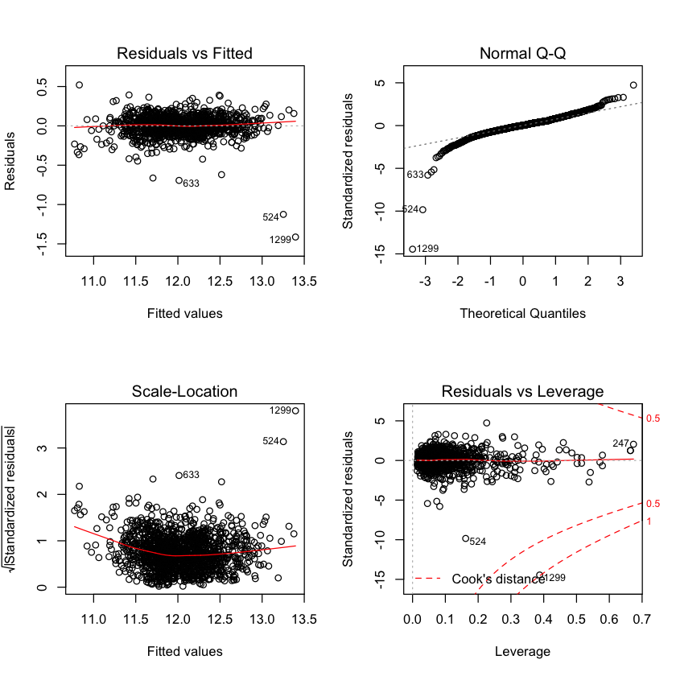

```python
par(mfrow=c(2,2))
plot(t.lm)
```

```python
# testset
for(i in del_attr){
    test[[i]]<-NULL}

for(i in names(test)){
    test[[i]]<-fillNa(test[[i]])
}


pr.lm<-predict(t.lm,test)
SalePrice<-exp(pr.lm)

train.lm<-train
test.lm<-test
#write.csv(cbind(Id,SalePrice),file = "lm_j.csv")
```

```python
summary(t.lm)
```

```
Call:
lm(formula = SalePrice ~ ., data = train)

Residuals:
     Min       1Q   Median       3Q      Max
-1.41314 -0.05634  0.00332  0.06131  0.52022

Coefficients:
                       Estimate Std. Error t value Pr(>|t|)
(Intercept)           8.105e+00  9.417e-01   8.606  < 2e-16 ***
MSZoningFV            3.967e-01  6.161e-02   6.439 1.68e-10 ***
MSZoningRH            4.133e-01  6.152e-02   6.718 2.73e-11 ***
MSZoningRL            3.860e-01  5.191e-02   7.437 1.84e-13 ***
MSZoningRM            3.557e-01  4.846e-02   7.341 3.69e-13 ***
LotFrontage          -3.120e-04  1.749e-04  -1.784 0.074641 .
LotArea               1.080e-06  4.306e-07   2.509 0.012242 *
LotShapeIR2           4.372e-02  2.201e-02   1.986 0.047233 *
LotShapeIR3          -1.294e-01  4.560e-02  -2.838 0.004607 **
LotShapeReg          -4.772e-03  8.069e-03  -0.591 0.554366
NeighborhoodBlueste  -3.698e-02  9.893e-02  -0.374 0.708641
NeighborhoodBrDale   -4.236e-02  5.642e-02  -0.751 0.452871
NeighborhoodBrkSide   2.254e-02  4.803e-02   0.469 0.638950
NeighborhoodClearCr   5.140e-02  4.568e-02   1.125 0.260757
NeighborhoodCollgCr   1.463e-02  3.781e-02   0.387 0.698808
NeighborhoodCrawfor   1.591e-01  4.353e-02   3.654 0.000268 ***
NeighborhoodEdwards  -9.357e-02  4.108e-02  -2.278 0.022908 *
NeighborhoodGilbert   6.329e-04  4.009e-02   0.016 0.987408
NeighborhoodIDOTRR   -3.160e-02  5.498e-02  -0.575 0.565541
NeighborhoodMeadowV  -1.455e-01  5.298e-02  -2.747 0.006098 **
NeighborhoodMitchel  -2.238e-02  4.199e-02  -0.533 0.594082
NeighborhoodNAmes    -2.364e-03  3.997e-02  -0.059 0.952852
NeighborhoodNoRidge   1.167e-01  4.286e-02   2.724 0.006542 **
NeighborhoodNPkVill   3.937e-03  5.611e-02   0.070 0.944074
NeighborhoodNridgHt   1.367e-01  3.814e-02   3.584 0.000351 ***
NeighborhoodNWAmes    3.359e-03  4.131e-02   0.081 0.935206
NeighborhoodOldTown  -3.690e-02  4.900e-02  -0.753 0.451558
NeighborhoodSawyer   -1.267e-02  4.203e-02  -0.301 0.763172
NeighborhoodSawyerW   3.474e-03  4.018e-02   0.086 0.931119
NeighborhoodSomerst   8.548e-02  4.557e-02   1.876 0.060901 .
NeighborhoodStoneBr   1.687e-01  4.227e-02   3.991 6.95e-05 ***
```

[output cut: 94 more lines]

```
PavedDriveY           3.594e-02  1.751e-02   2.053 0.040248 *
WoodDeckSF            1.202e-04  3.043e-05   3.951 8.20e-05 ***
EnclosedPorch         9.964e-05  6.331e-05   1.574 0.115735
ScreenPorch           2.814e-04  6.380e-05   4.410 1.12e-05 ***
SaleConditionAdjLand  9.203e-02  7.306e-02   1.260 0.208007
SaleConditionAlloca   5.458e-02  4.316e-02   1.265 0.206172
SaleConditionFamily   1.231e-02  3.182e-02   0.387 0.698795
SaleConditionNormal   7.196e-02  1.391e-02   5.173 2.66e-07 ***
SaleConditionPartial  9.269e-02  1.963e-02   4.722 2.58e-06 ***
---
Signif. codes:  0 ‘***’ 0.001 ‘**’ 0.01 ‘*’ 0.05 ‘.’ 0.1 ‘ ’ 1

Residual standard error: 0.1249 on 1326 degrees of freedom
Multiple R-squared:  0.9111,	Adjusted R-squared:  0.9022
F-statistic: 102.2 on 133 and 1326 DF,  p-value: < 2.2e-16
```

## svm model

support vector machines are supervised learning models with associated learning algorithms that analyze data used for classification and regression analysis. It is characterized by usage of kernels, absence of local minima, sparseness of the solution and capacity control obtained by acting on the margin, or on number of support vectors, etc.

SVM can be used to avoid difficulties of using linear functions in the high dimensional feature space and optimization problem is transformed into dual convex quadratic programmes. In regression case the loss function is used to penalize errors that are grater than threshold - . Such loss functions usually lead to the sparse representation of the decision rule, giving significant algorithmic and representational advantages.

### Tuning Parameters in SVM models

One Difficulty I find in SVM is to find the right parameters.Here I use the tune()functions in R package{e1071}. It cost a lot of time when tuning the SVM models, so here I use greedy techique.

1. First I set`ranges=list(cost=10^(-1:2))` to tune the `cost`,
2. use the optimal `cost` to tune the `epsilon`,set`ranges=list(epsilon=10^(-1:2)`, to find the best epsilon.
3. Later tune the SVM again in smaller ranges.

Below is a piece of my final tuneing SVM code.(It cost a lot of time So I comment this code)

```python
#for(i in names(train)){
 # train[[i]]<-as.numeric(train[[i]])
#}

#pr.lm<-tune(svm,SalePrice~.,data = train,ranges = list(cost=c(1,10),kernel=c("linear","radial"),epsilon=c(0.1,1,0.05,0.2)))
#fit.svm<-pr.lm$best.model
#summary(fit.svm)
#pr.lm <- predict(fit.svm, train[-index, ])
#error.lm <-sqrt(sum((train[-index, length(train)] - pr.lm) ^ 2) / length(pr.lm))

#for(i in names(test)){
#  test[[i]]<-as.numeric(test[[i]])
#}
#pr.lm<-predict(fit.svm,test)
#SalePrice<-exp(pr.lm)
#SalePrice
#write.csv(cbind(Id,SalePrice),file = "svm_j.csv")
```

## Lasso Model

In statistics and machine learning, **lasso (least absolute shrinkage and selection operator)** is a regression analysis method that performs both variable selection and regularization in order to enhance the prediction accuracy and interpretability of the statistical model it produces.

For Linear Regression,we have $$ y(\mathbf{x,w}) = \sum_{j=0}^{M-1} w_j \phi_j(\mathbf x) = \mathbf{w^\top \phi(x)} $$ where the sum-of-squares error function is deﬁned by $$ E_D(\mathbf w) = \frac{1}{2}\sum_{n=1}^N \{t_n-\mathbf w^\top\mathbf \phi(\mathbf x_n)\}^2 $$

We could use Maximum likelihood and least squares to understand our linear regression problems. So at last,we use this formula. $$ \frac{1}{2}\sum_{n=1}^N \{t_n-\mathbf w^\top\mathbf \phi(\mathbf x_n)\}^2 + \frac \lambda 2 \sum_{j=1}^M |w_j|^q $$

When $q=1$, we called it Lasso. When $\lambda$ is larger enough, some $w_j=0$ which makes our model sparse. **LASSO does both parameter shrinkage and variable selection automatically**

**Before using Lasso, I transform all the category attributes in to dummy variables.**(Lasso do not support factor variables)

```python
library(lars)
price<-train$SalePrice
train$SalePrice<-NULL

train_test<-rbind(train,test)

for (i in names(train_test)){
  if(class(train_test[[i]])=='factor'){
    a<-model.matrix(~train_test[[i]])
    train_test[[i]]<-NULL
    a.colname<-colnames(a)
    for(j in seq(length(a.colname))){
      name<-a.colname[j]
      train_test[[name]]<-a[,j]
    }
  }
}

train<-train_test[1:1460,]
train$price<-price
test<-train_test[1461:length(train_test[,1]),]


x <- as.matrix(train[,1:(length(train)-1)])
xtest <- as.matrix(train[-index,1:(length(train)-1)])
y <- as.matrix(train[["price"]])
fit <- lars(x, y, type="lasso")
summary(fit)
best_step <- fit$df[which.min(fit$RSS)]
pr.lm <- predict(fit, test, s=best_step, type="fit")$fit
SalePrice<-exp(pr.lm)
#write.csv(cbind(Id,SalePrice),file = "lasso.csv")
```

|  | Df | Rss | Cp |
| --- | --- | --- | --- |
| 0 | 1 | 232.80066 | 12383.2724 |
| 1 | 2 | 143.11131 | 7052.7503 |
| 2 | 3 | 123.27147 | 5875.1632 |
| 3 | 4 | 85.86661 | 3653.2397 |
| 4 | 5 | 76.08631 | 3073.7471 |
| 5 | 6 | 67.12613 | 2543.0155 |
| 6 | 7 | 65.56513 | 2452.2059 |
| 7 | 8 | 57.56824 | 1978.7467 |
| 8 | 9 | 55.66683 | 1867.6977 |
| 9 | 10 | 48.84274 | 1463.9681 |
| 10 | 11 | 45.68629 | 1278.3000 |
| 11 | 12 | 45.53712 | 1271.4307 |
| 12 | 13 | 41.18823 | 1014.8657 |
| 13 | 14 | 40.48004 | 974.7596 |
| 14 | 15 | 39.03409 | 890.7903 |
| 15 | 16 | 38.37409 | 853.5498 |
| 16 | 17 | 37.17341 | 784.1625 |
| 17 | 18 | 37.07154 | 780.1058 |
| 18 | 19 | 37.00055 | 777.8849 |
| 19 | 20 | 36.95248 | 777.0270 |
| 20 | 21 | 36.81133 | 770.6348 |
| 21 | 22 | 36.60791 | 760.5404 |
| 22 | 23 | 36.43059 | 751.9977 |
| 23 | 22 | 36.30099 | 742.2924 |
| 24 | 23 | 36.10246 | 732.4888 |
| 25 | 24 | 35.68605 | 709.7310 |
| 26 | 25 | 35.59248 | 706.1674 |
| 27 | 26 | 35.21049 | 685.4563 |
| 28 | 27 | 35.03050 | 676.7546 |
| 29 | 28 | 34.88619 | 670.1748 |
| ⋮ | ⋮ | ⋮ | ⋮ |
| 97 | 92 | 23.49035 | 120.6296 |
| 98 | 93 | 23.48173 | 122.1172 |
| 99 | 94 | 23.43181 | 121.1491 |
| 100 | 95 | 23.37167 | 119.5739 |
| 101 | 96 | 23.26833 | 115.4294 |
| 102 | 97 | 23.26336 | 117.1337 |
| 103 | 96 | 23.08100 | 104.2918 |
| 104 | 97 | 23.02568 | 103.0028 |
| 105 | 98 | 22.97232 | 101.8302 |
| 106 | 99 | 22.97184 | 103.8016 |
| 107 | 100 | 22.94717 | 104.3347 |
| 108 | 99 | 22.93231 | 101.4511 |
| 109 | 100 | 22.90960 | 102.1008 |
| 110 | 101 | 22.86185 | 101.2622 |
| 111 | 102 | 22.85014 | 102.5658 |
| 112 | 103 | 22.83313 | 103.5543 |
| 113 | 104 | 22.83258 | 105.5216 |
| 114 | 105 | 22.81167 | 106.2784 |
| 115 | 104 | 22.80138 | 103.6666 |
| 116 | 105 | 22.77946 | 104.3634 |
| 117 | 106 | 22.76192 | 105.3209 |
| 118 | 107 | 22.75111 | 106.6778 |
| 119 | 106 | 22.73981 | 104.0061 |
| 120 | 107 | 22.72264 | 104.9851 |
| 121 | 108 | 22.72254 | 106.9790 |
| 122 | 107 | 22.72074 | 104.8720 |
| 123 | 108 | 22.71279 | 106.3995 |
| 124 | 109 | 22.69997 | 107.6376 |
| 125 | 110 | 22.69948 | 109.6082 |
| 126 | 111 | 22.68925 | 111.0000 |

# Ensemble Techniques

[figure not shown]

```python
# initialize SalePrice and error
SalePrice<-cbind(rep(0,1459))
error<-c(1)
train<-train.lm
test<-test.lm

for(i in names(test)){
  test[[i]]<-as.numeric(test[[i]])
}
for(i in names(train)){
  train[[i]]<-as.numeric(train[[i]])
}

# repeat the training step for 30 times
for (i in runif(30,0.85,0.95)){

    # random sampling
  index1<-sample(1:nrow(train),round(i*nrow(train)))
     #train model
  t.lm<-lm(SalePrice ~ .,train[index1,])
    #cross validation
  pr.lm<-predict(t.lm,train[-index1,])

  error.lm<- sqrt(sum((train$SalePrice[-index1]-pr.lm)^2)/length(pr.lm))
  error<-c(error,error.lm)
    # predict results
  test.lm<-predict(t.lm,test)
  test.lm<-exp(test.lm)
  SalePrice<-cbind(SalePrice,test.lm)
}

# only Select the error rate<0.15 predicted results
temp<-which(error<0.15)
price<-SalePrice[,temp]
# The Final result is the meal value of SalePrice
SalePrice<-apply(SalePrice,1,mean)
#write.csv(cbind(Id,SalePrice),file = "lm1.csv")
```

### Baging

[figure not shown]

```python
lasso1<-read.csv("lasso1.csv")
svm1<-read.csv("svm1.csv")
lm1<-read.csv("lm1.csv")
SalePrice<-1/3*(lasso1$SalePrice+svm1$SalePrice+lm1$SalePrice)
write.csv(cbind(Id,SalePrice),file = "final.csv")
```

# Discussion and Conclusion

### Final Kaggle Score

[figure not shown]

### Problems

The Kaggle housing price prediction is a real example in Ames,Iowa. This competition both predict the housing price and help me apply the technique I learned during the Machine learning class. During this competition I learn a lot and also had deeper understanding about Machine learning algorithms, especially the feature selection, and the bagging technique. But there are still doubts that puzzeled me.

- How to deal with outliers?  
  In the data cleaning procedure, I tried to remove all the SalePrices outliers, which include SalePrice more than 4.5e5, but I do not know why the error is greater than removed before.
- Why does random feature does not work?  
  In ensembling models part, I also tried to randomly select features to train the model, then select the the model with best performance(Like randomForest), but the prediction is really poor, it is not as good as selecting features artificially.

### Conclusion

- The **feature selection** is very important. I tried to give the prediction using multiple different feature subset, and later I found a good feature selection is very important.
- The **Model Selection** is also very important. Cause I also tried to use `rpart` ,`tree` and `nnet` to predict, which gave very bad prediction.
- Visualzing data can give a direct hint about how to dealing with the data.
- Sometimes do not make the problems complicated, some naive solutions and models can also give a good result.

# References

1. Pattern Recognition and Machine Learning,ISBN-10: 0-387-31073-8,Christopher M. Bishop
2. Statistical foundations of machine learning,Gianluca Bontempi
3. [Scikit-learning](http://scikit-learn.org/stable/tutorial/machine_learning_map/)
4. [Support Vector Machines](http://www.saedsayad.com/support_vector_machine.htm)
5. [Support Vector Machine Regression](http://kernelsvm.tripod.com)
6. The Art of R Programming, Norman Matloff
7. R in Action, Robert I. kabocoff